# Project: Brazil's No Show Appointments Database

- Introduction
- Data Wrangling
- Exploratory Data Analysis
- Conclusions

## Introduction

> For the purpose of the project I will be using the csv file containing data collected from Brazil about whether or not patients showed up to their medical appointments.

> The description provided for this data set "This dataset collects information from 100k medical appointments in Brazil and is focused on the question of whether or not patients show up for their appointment. A number of characteristics about the patient are included in each row.
> - ‘ScheduledDay’ tells us on what day the patient set up their appointment.
> - ‘Neighborhood’ indicates the location of the hospital.
> - ‘Scholarship’ indicates whether or not the patient is enrolled in Brasilian welfare program Bolsa Família.
> - 'No-show' column says ‘No’ if the patient showed up to their appointment, and ‘Yes’ if they did not show up."

> The question that this analysis will help answer is *"What factors make a patient more likely to show up for an appointment?"*.

> The dependent Factor is No-show status The independent Factors that are going to be investigated are Age, Scholarship and Received SMS

```python
%matplotlib inline
%config InlineBackend.figure_format = 'retina'
import matplotlib.pyplot as plt
import numpy as np
import pandas as pd
import seaborn as sns
import csv
```

## Data Wrangling

### General Properties

```python
# Loading the  data and printing out a few lines.
df = pd.read_csv('noshowappointments-kagglev2-may-2016.csv')
df.head()
```

|  | PatientId | AppointmentID | Gender | ScheduledDay | AppointmentDay | Age | Neighbourhood | Scholarship | Hipertension | Diabetes | Alcoholism | Handcap | SMS_received | No-show |
| --- | --- | --- | --- | --- | --- | --- | --- | --- | --- | --- | --- | --- | --- | --- |
| 0 | 2.987250e+13 | 5642903 | F | 2016-04-29T18:38:08Z | 2016-04-29T00:00:00Z | 62 | JARDIM DA PENHA | 0 | 1 | 0 | 0 | 0 | 0 | No |
| 1 | 5.589978e+14 | 5642503 | M | 2016-04-29T16:08:27Z | 2016-04-29T00:00:00Z | 56 | JARDIM DA PENHA | 0 | 0 | 0 | 0 | 0 | 0 | No |
| 2 | 4.262962e+12 | 5642549 | F | 2016-04-29T16:19:04Z | 2016-04-29T00:00:00Z | 62 | MATA DA PRAIA | 0 | 0 | 0 | 0 | 0 | 0 | No |
| 3 | 8.679512e+11 | 5642828 | F | 2016-04-29T17:29:31Z | 2016-04-29T00:00:00Z | 8 | PONTAL DE CAMBURI | 0 | 0 | 0 | 0 | 0 | 0 | No |
| 4 | 8.841186e+12 | 5642494 | F | 2016-04-29T16:07:23Z | 2016-04-29T00:00:00Z | 56 | JARDIM DA PENHA | 0 | 1 | 1 | 0 | 0 | 0 | No |

```python
#show how many rows and columns
df.shape
```

```
(110527, 14)
```

```python
#show information about data
df.info()
```

```
<class 'pandas.core.frame.DataFrame'>
RangeIndex: 110527 entries, 0 to 110526
Data columns (total 14 columns):
 #   Column          Non-Null Count   Dtype
---  ------          --------------   -----
 0   PatientId       110527 non-null  float64
 1   AppointmentID   110527 non-null  int64
 2   Gender          110527 non-null  object
 3   ScheduledDay    110527 non-null  object
 4   AppointmentDay  110527 non-null  object
 5   Age             110527 non-null  int64
 6   Neighbourhood   110527 non-null  object
 7   Scholarship     110527 non-null  int64
 8   Hipertension    110527 non-null  int64
 9   Diabetes        110527 non-null  int64
 10  Alcoholism      110527 non-null  int64
 11  Handcap         110527 non-null  int64
 12  SMS_received    110527 non-null  int64
 13  No-show         110527 non-null  object
dtypes: float64(1), int64(8), object(5)
memory usage: 11.8+ MB
```

```python
df.describe()
```

|  | PatientId | AppointmentID | Age | Scholarship | Hipertension | Diabetes | Alcoholism | Handcap | SMS_received |
| --- | --- | --- | --- | --- | --- | --- | --- | --- | --- |
| count | 1.105270e+05 | 1.105270e+05 | 110527.000000 | 110527.000000 | 110527.000000 | 110527.000000 | 110527.000000 | 110527.000000 | 110527.000000 |
| mean | 1.474963e+14 | 5.675305e+06 | 37.088874 | 0.098266 | 0.197246 | 0.071865 | 0.030400 | 0.022248 | 0.321026 |
| std | 2.560949e+14 | 7.129575e+04 | 23.110205 | 0.297675 | 0.397921 | 0.258265 | 0.171686 | 0.161543 | 0.466873 |
| min | 3.921784e+04 | 5.030230e+06 | -1.000000 | 0.000000 | 0.000000 | 0.000000 | 0.000000 | 0.000000 | 0.000000 |
| 25% | 4.172614e+12 | 5.640286e+06 | 18.000000 | 0.000000 | 0.000000 | 0.000000 | 0.000000 | 0.000000 | 0.000000 |
| 50% | 3.173184e+13 | 5.680573e+06 | 37.000000 | 0.000000 | 0.000000 | 0.000000 | 0.000000 | 0.000000 | 0.000000 |
| 75% | 9.439172e+13 | 5.725524e+06 | 55.000000 | 0.000000 | 0.000000 | 0.000000 | 0.000000 | 0.000000 | 1.000000 |
| max | 9.999816e+14 | 5.790484e+06 | 115.000000 | 1.000000 | 1.000000 | 1.000000 | 1.000000 | 4.000000 | 1.000000 |

```python
#count rows with missing or null values
df.isnull().sum()
```

```
PatientId         0
AppointmentID     0
Gender            0
ScheduledDay      0
AppointmentDay    0
Age               0
Neighbourhood     0
Scholarship       0
Hipertension      0
Diabetes          0
Alcoholism        0
Handcap           0
SMS_received      0
No-show           0
dtype: int64
```

```python
#count unique values
df.nunique()
```

```
PatientId          62299
AppointmentID     110527
Gender                 2
ScheduledDay      103549
AppointmentDay        27
Age                  104
Neighbourhood         81
Scholarship            2
Hipertension           2
Diabetes               2
Alcoholism             2
Handcap                5
SMS_received           2
No-show                2
dtype: int64
```

```python
#check for duplicated data
print(sum(df.duplicated()))
```

```
0
```

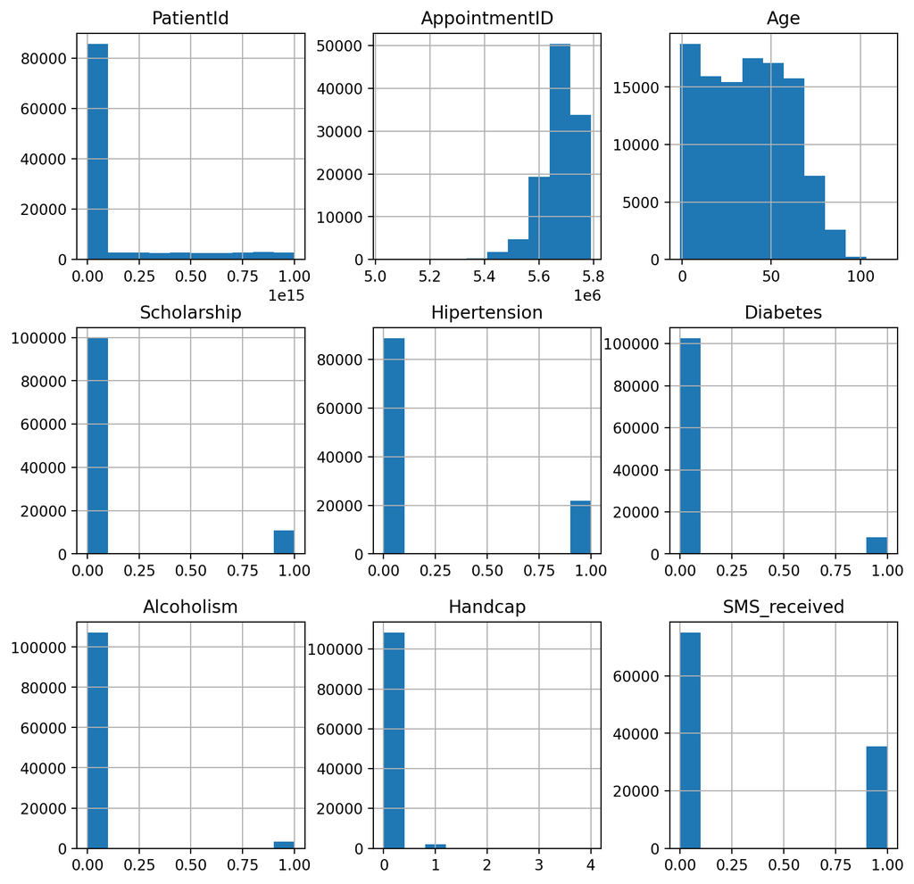

```python
# show a visualization of the data using the hist function to better understand the trends in the data set
df.hist(figsize=(10,10));
```

### Data Cleaning

> The Data set has no duplicates or missing values to be cleaned or dropped

```python
#find which rows have age = -1 using the query function
df.query('Age == -1')
```

|  | PatientId | AppointmentID | Gender | ScheduledDay | AppointmentDay | Age | Neighbourhood | Scholarship | Hipertension | Diabetes | Alcoholism | Handcap | SMS_received | No-show |
| --- | --- | --- | --- | --- | --- | --- | --- | --- | --- | --- | --- | --- | --- | --- |
| 99832 | 4.659432e+14 | 5775010 | F | 2016-06-06T08:58:13Z | 2016-06-06T00:00:00Z | -1 | ROMÃO | 0 | 0 | 0 | 0 | 0 | 0 | No |

```python
# drop row with Age = -1 as it is an invalid entry
df.drop(df[df.Age==-1].index,inplace=True)
```

```python
# run the query aagin to make sure the row was dropped
df.query('Age == -1')
```

|  | PatientId | AppointmentID | Gender | ScheduledDay | AppointmentDay | Age | Neighbourhood | Scholarship | Hipertension | Diabetes | Alcoholism | Handcap | SMS_received | No-show |
| --- | --- | --- | --- | --- | --- | --- | --- | --- | --- | --- | --- | --- | --- | --- |

```python
#run the decribe function again to see the new values
df.describe()
```

|  | PatientId | AppointmentID | Age | Scholarship | Hipertension | Diabetes | Alcoholism | Handcap | SMS_received |
| --- | --- | --- | --- | --- | --- | --- | --- | --- | --- |
| count | 1.105260e+05 | 1.105260e+05 | 110526.000000 | 110526.000000 | 110526.000000 | 110526.000000 | 110526.000000 | 110526.000000 | 110526.000000 |
| mean | 1.474934e+14 | 5.675304e+06 | 37.089219 | 0.098266 | 0.197248 | 0.071865 | 0.030400 | 0.022248 | 0.321029 |
| std | 2.560943e+14 | 7.129544e+04 | 23.110026 | 0.297676 | 0.397923 | 0.258266 | 0.171686 | 0.161543 | 0.466874 |
| min | 3.921784e+04 | 5.030230e+06 | 0.000000 | 0.000000 | 0.000000 | 0.000000 | 0.000000 | 0.000000 | 0.000000 |
| 25% | 4.172536e+12 | 5.640285e+06 | 18.000000 | 0.000000 | 0.000000 | 0.000000 | 0.000000 | 0.000000 | 0.000000 |
| 50% | 3.173184e+13 | 5.680572e+06 | 37.000000 | 0.000000 | 0.000000 | 0.000000 | 0.000000 | 0.000000 | 0.000000 |
| 75% | 9.438963e+13 | 5.725523e+06 | 55.000000 | 0.000000 | 0.000000 | 0.000000 | 0.000000 | 0.000000 | 1.000000 |
| max | 9.999816e+14 | 5.790484e+06 | 115.000000 | 1.000000 | 1.000000 | 1.000000 | 1.000000 | 4.000000 | 1.000000 |

```python
#change column names to lower case
df.rename(columns=lambda x: x.lower(), inplace =True)

#show one row to confirm change
df.head(1)
```

|  | patientid | appointmentid | gender | scheduledday | appointmentday | age | neighbourhood | scholarship | hipertension | diabetes | alcoholism | handcap | sms_received | no-show |
| --- | --- | --- | --- | --- | --- | --- | --- | --- | --- | --- | --- | --- | --- | --- |
| 0 | 2.987250e+13 | 5642903 | F | 2016-04-29T18:38:08Z | 2016-04-29T00:00:00Z | 62 | JARDIM DA PENHA | 0 | 1 | 0 | 0 | 0 | 0 | No |

```python
# rename columns to add '_' between multiple words and fix misspelled words

df.rename(columns = {'patientid':'patient_id','appointmentid':'appointment_id','scheduledday':'scheduled_day',
                     'appointmentday':'appointment_day','hipertension':'hypertension', 'handcap' : 'handicap',
                  'no-show':'no_show'}, inplace =True)

#show one row to confirm change
df.head(1)
```

|  | patient_id | appointment_id | gender | scheduled_day | appointment_day | age | neighbourhood | scholarship | hypertension | diabetes | alcoholism | handicap | sms_received | no_show |
| --- | --- | --- | --- | --- | --- | --- | --- | --- | --- | --- | --- | --- | --- | --- |
| 0 | 2.987250e+13 | 5642903 | F | 2016-04-29T18:38:08Z | 2016-04-29T00:00:00Z | 62 | JARDIM DA PENHA | 0 | 1 | 0 | 0 | 0 | 0 | No |

## Exploratory Data Analysis

### Q1 Which age group had the most number of missed appointments?

> First I will create bin edges to cut the data into groups

```python
# create bin edge to cut the age data into groups
bins = [-1, 12, 18, 30, 50, 60, 70, 80, 90, 100, 110, 120]

#labels for the age groups
labels = ['child', 'teen', 'young adult', 'middle age', '50s', '60s', '70s', '80s', '90s', '100s', '110s']
```

```python
#create age_group column
df['age_group'] = pd.cut(df['age'], bins, labels=labels)
```

```python
#show new column
df.head()
```

|  | patient_id | appointment_id | gender | scheduled_day | appointment_day | age | neighbourhood | scholarship | hypertension | diabetes | alcoholism | handicap | sms_received | no_show | age_group |
| --- | --- | --- | --- | --- | --- | --- | --- | --- | --- | --- | --- | --- | --- | --- | --- |
| 0 | 2.987250e+13 | 5642903 | F | 2016-04-29T18:38:08Z | 2016-04-29T00:00:00Z | 62 | JARDIM DA PENHA | 0 | 1 | 0 | 0 | 0 | 0 | No | 60s |
| 1 | 5.589978e+14 | 5642503 | M | 2016-04-29T16:08:27Z | 2016-04-29T00:00:00Z | 56 | JARDIM DA PENHA | 0 | 0 | 0 | 0 | 0 | 0 | No | 50s |
| 2 | 4.262962e+12 | 5642549 | F | 2016-04-29T16:19:04Z | 2016-04-29T00:00:00Z | 62 | MATA DA PRAIA | 0 | 0 | 0 | 0 | 0 | 0 | No | 60s |
| 3 | 8.679512e+11 | 5642828 | F | 2016-04-29T17:29:31Z | 2016-04-29T00:00:00Z | 8 | PONTAL DE CAMBURI | 0 | 0 | 0 | 0 | 0 | 0 | No | child |
| 4 | 8.841186e+12 | 5642494 | F | 2016-04-29T16:07:23Z | 2016-04-29T00:00:00Z | 56 | JARDIM DA PENHA | 0 | 1 | 1 | 0 | 0 | 0 | No | 50s |

```python
#show number of values in each age group by using groupby function
df.groupby([df['age_group']]).size()
```

```
age_group
child          21036
teen            7830
young adult    16765
middle age     29472
50s            15661
60s            11189
70s             5721
80s             2544
90s              301
100s               2
110s               5
dtype: int64
```

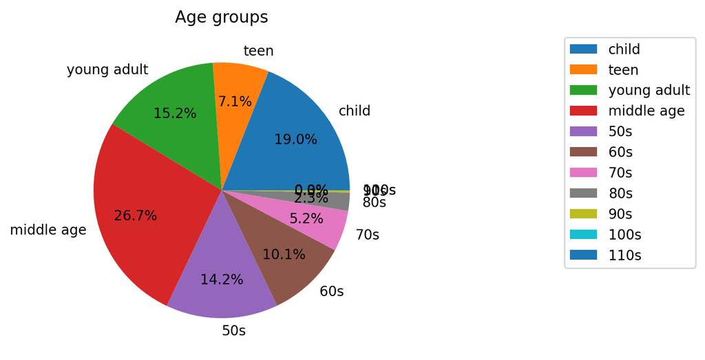

```python
# bar chart of age groups

fig, ax = plt.subplots(figsize=(5, 10))
df.groupby([df['age_group']]).size().plot(kind='pie', title='Age groups', autopct='%1.1f%%', pctdistance=0.7, ax=ax)
plt.tight_layout()
plt.legend(loc='upper right', bbox_to_anchor=(2, 1))
plt.subplots_adjust(left=0.1, bottom=0.1, right=0.75)
plt.show();
```

Now I will explore the relationship between the age and the no_show status. First I will group the data by age group and no show status

```python
# using groupby function to sort the data based on age and no show status
no_show_counts = df.groupby(['no_show', 'age_group']).size()['Yes']
print(no_show_counts)
```

```
age_group
child          4307
teen           2040
young adult    4143
middle age     6102
50s            2721
60s            1648
70s             889
80s             407
90s              59
100s              0
110s              3
dtype: int64
```

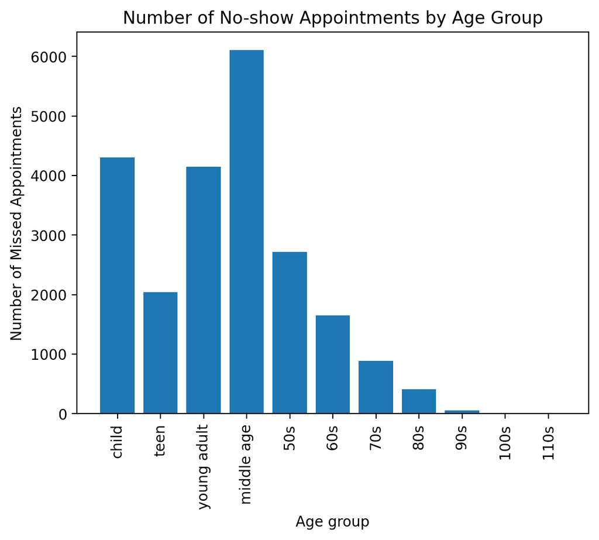

```python
# create a bar chart to explore the correlation between age group and no show status
#for patients who did not show up for their appointments

plt.bar(no_show_counts.index, no_show_counts.values)
plt.xlabel('Age group')
plt.ylabel('Number of Missed Appointments')
plt.title('Number of No-show Appointments by Age Group')
plt.xticks(rotation=90)
plt.show();
```

> By examining the data through the groupby function and further visualization through the bar chart, it becomes apparent that the age group with the most missed appoitments is the middle age group aging 30-50 years old.

### Q2: Does having a Scholarship cause patients to show up for their appointments?

> For the scholarship column 0 means a patient does not have a scholarship and 1 means a patient has a scholarship.

```python
# First I will use the value_counts function to determine how many patients have scholarships
# vs how many don't have a sholarship
df.value_counts('scholarship')
```

```
scholarship
0    99665
1    10861
dtype: int64
```

```python
# using groupby to filter by scholarship and  no-show status
df.groupby(["scholarship","no_show"]).size()
```

```
scholarship  no_show
0            No         79924
             Yes        19741
1            No          8283
             Yes         2578
dtype: int64
```

```python
#create masks for show vs no_show status
no_show = df.no_show == 'Yes'
show = df.no_show == 'No'
```

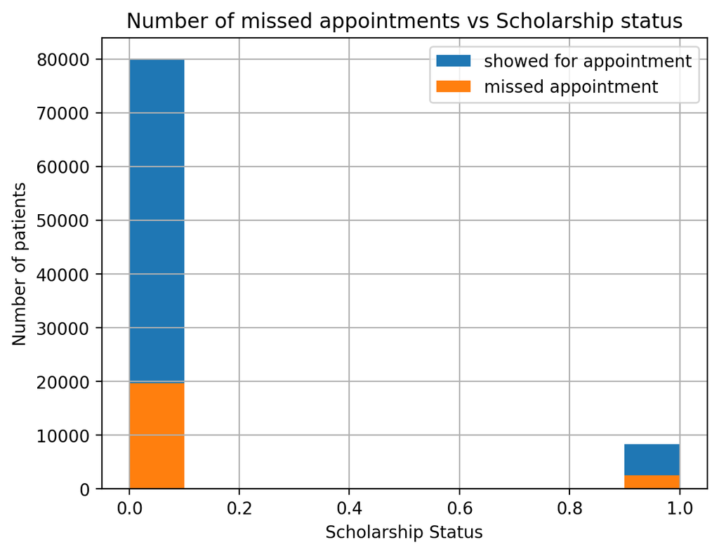

```python
#create a bar chart to visualize the data and the correlation between having scholarship and the no-show status
df.scholarship[show].hist(label = 'showed for appointment');
df.scholarship[no_show].hist(label = 'missed appointment');
plt.title('Number of missed appointments vs Scholarship status')
plt.xlabel('Scholarship Status')
plt.ylabel('Number of patients')
plt.legend();
```

> By grouping scholarship status along with no-show status using the groupby function and further visualizing the data using bar chart it seems that more patients without a scholarship showed up for their appointment than patients who have a scholarship.

> Based of the data generated 90% of the patients do not have a scholarship and out of those patients 80% showed up for their appointments. On the other hand, Only 10% of the patients had a scholarship and out of those patients 76% showed up for their appointments.

### Q3: Does receiving an SMS cause more patients to show up for their appointments?

> For the sms_received column 0 means a patient did not recieve an sms and 1 means a patient received an sms.

```python
# First I will use the value_counts function to determine how many patients have received an sms
# vs how many didn't receive an sms
df.value_counts('sms_received')
```

```
sms_received
0    75044
1    35482
dtype: int64
```

```python
# using groupby to filter by scholarship and no-show status
df.groupby(["sms_received","no_show"]).size()
```

```
sms_received  no_show
0             No         62509
              Yes        12535
1             No         25698
              Yes         9784
dtype: int64
```

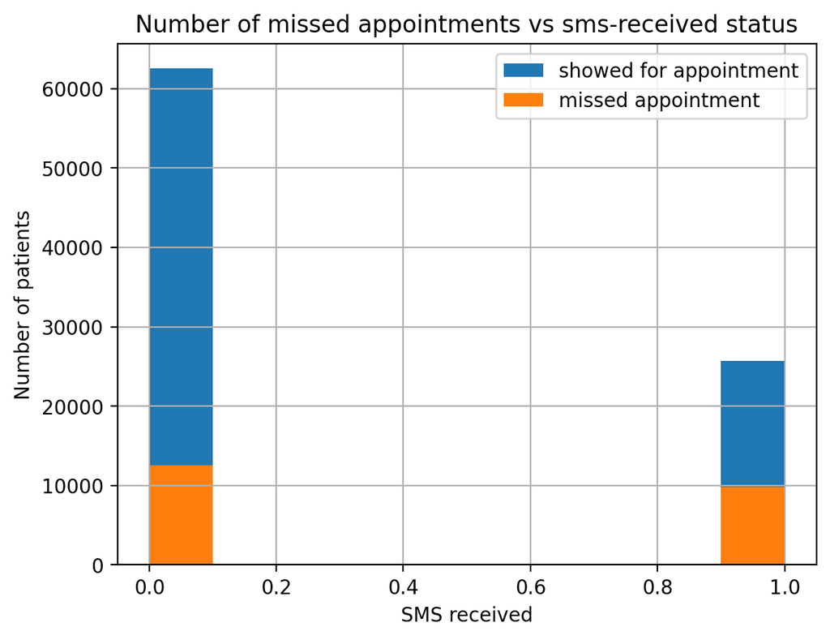

```python
#create a bar chart to visualize the data and the correlation between receiveing an sms and the no-show status
df.sms_received[show].hist(label = 'showed for appointment');
df.sms_received[no_show].hist(label = 'missed appointment');
plt.title('Number of missed appointments vs sms-received status');
plt.xlabel('SMS received')
plt.ylabel('Number of patients')
plt.legend();
```

> By grouping the status of receiveing an sms along with no-show status using the groupby function and further visualizing the data using bar chart it seems that more patients showed up for their appointment without receiving an sms than patients who have received an sms.

> Based of the data generated 68% of the patients did not recieve an sms and out of those patients 83% showed up for their appointments. On the other hand, 32% of the patients received an sms and out of those patients 72% showed up for their appointments.

## Conclusions

It's important to note that this analysis has its limitations. I did not perform any statistical tests, so my conclusions are based solely on observed correlations in the data. The findings of this study provide valuable insights for healthcare providers to develop targeted strategies to improve appointment scheduling and patient communication, but additional research is necessary to fully understand the factors that influence attendance rates.

## References:

> These are links to stack overflow discussions that helped me troubleshoot my code
> - https://stackoverflow.com/questions/43272206/python-legend-overlaps-with-the-pie-chart
> - https://stackoverflow.com/questions/33149428/modify-the-legend-of-pandas-bar-plot
> - https://stackoverflow.com/questions/34094596/python-matplotlib-pyplot-pie-charts-how-to-remove-the-label-on-the-left-side